# Crossvalidation and Regularization

Fall 2022: Peter Ralph

https://uodsci.github.io/dsci345

# A cautionary tale

Here are weekly COVID case counts across the US states plus DC, PR, and GU for 2020, a 48 x 53 matrix:

```python
covid
```

| date | AK | AL | AR | AZ | CA | CO | CT | DC | DE | FL | ... | SD | TN | TX | UT | VA | VT | WA | WI | WV | WY |
| --- | --- | --- | --- | --- | --- | --- | --- | --- | --- | --- | --- | --- | --- | --- | --- | --- | --- | --- | --- | --- | --- |
| 2020-02-03 | 0.0 | 0.0 | 0.0 | 0.0 | 6.0 | 0.0 | 0.0 | 0.0 | 1.0 | 0.0 | ... | 0.0 | 0.0 | 0.0 | 0.0 | 0.0 | 0.0 | 0.0 | 0.0 | 0.0 | 0.0 |
| 2020-02-10 | 0.0 | 0.0 | 0.0 | 0.0 | 0.0 | 0.0 | 0.0 | 0.0 | 2.0 | 0.0 | ... | 0.0 | 0.0 | 0.0 | 0.0 | 0.0 | 0.0 | 0.0 | 0.0 | 0.0 | 0.0 |
| 2020-02-17 | 0.0 | 0.0 | 0.0 | 0.0 | 2.0 | 0.0 | 0.0 | 0.0 | 2.0 | 0.0 | ... | 0.0 | 0.0 | 0.0 | 0.0 | 0.0 | 0.0 | 0.0 | 0.0 | 0.0 | 0.0 |
| 2020-02-24 | 0.0 | 0.0 | 0.0 | 0.0 | 17.0 | 0.0 | 0.0 | 0.0 | 2.0 | 0.0 | ... | 0.0 | 0.0 | 0.0 | 0.0 | 0.0 | 0.0 | 0.0 | 0.0 | 0.0 | 0.0 |
| 2020-03-02 | 0.0 | 0.0 | 0.0 | 0.0 | 14.0 | 1.0 | 0.0 | 0.0 | 0.0 | 2.0 | ... | 0.0 | 0.0 | 0.0 | 0.0 | 0.0 | 0.0 | 0.0 | 0.0 | 0.0 | 0.0 |
| 2020-03-09 | 0.0 | 0.0 | 0.0 | 5.0 | 94.0 | 11.0 | 1.0 | 2.0 | 0.0 | 16.0 | ... | 0.0 | 0.0 | 12.0 | 1.0 | 2.0 | 1.0 | 153.0 | 1.0 | 0.0 | 0.0 |
| 2020-03-16 | 1.0 | 36.0 | 17.0 | 12.0 | 259.0 | 135.0 | 40.0 | 20.0 | 7.0 | 138.0 | ... | 10.0 | 10.0 | 44.0 | 28.0 | 49.0 | 7.0 | 656.0 | 52.0 | 0.0 | 3.0 |
| 2020-03-23 | 37.0 | 188.0 | 180.0 | 235.0 | 1341.0 | 582.0 | 374.0 | 115.0 | 58.0 | 1065.0 | ... | 18.0 | 495.0 | 231.0 | 251.0 | 203.0 | 60.0 | 1212.0 | 363.0 | 20.0 | 23.0 |
| 2020-03-30 | 80.0 | 770.0 | 307.0 | 904.0 | 4030.0 | 1890.0 | 2156.0 | 358.0 | 245.0 | 4408.0 | ... | 73.0 | 1037.0 | 2587.0 | 526.0 | 766.0 | 168.0 | 2553.0 | 805.0 | 125.0 | 69.0 |
| 2020-04-06 | 73.0 | 1076.0 | 411.0 | 1299.0 | 8573.0 | 2572.0 | 4335.0 | 602.0 | 475.0 | 7585.0 | ... | 187.0 | 2117.0 | 4399.0 | 910.0 | 1858.0 | 274.0 | 3222.0 | 1219.0 | 200.0 | 117.0 |
| 2020-04-13 | 86.0 | 1789.0 | 495.0 | 1246.0 | 8012.0 | 2719.0 | 6475.0 | 858.0 | 921.0 | 6979.0 | ... | 580.0 | 1730.0 | 6633.0 | 676.0 | 2869.0 | 191.0 | 2303.0 | 988.0 | 281.0 | 161.0 |
| 2020-04-20 | 44.0 | 1288.0 | 554.0 | 1362.0 | 8630.0 | 2390.0 | 6434.0 | 972.0 | 1097.0 | 5966.0 | ... | 817.0 | 1721.0 | 5552.0 | 867.0 | 3243.0 | 55.0 | 1899.0 | 1071.0 | 276.0 | 55.0 |
| 2020-04-27 | 24.0 | 1457.0 | 1091.0 | 1652.0 | 12486.0 | 3779.0 | 6182.0 | 965.0 | 1448.0 | 5545.0 | ... | 560.0 | 2556.0 | 5839.0 | 1048.0 | 4545.0 | 31.0 | 1706.0 | 1582.0 | 175.0 | 92.0 |
| 2020-05-04 | 25.0 | 1581.0 | 414.0 | 2203.0 | 11473.0 | 3364.0 | 3976.0 | 1278.0 | 1310.0 | 4489.0 | ... | 423.0 | 3516.0 | 7035.0 | 1099.0 | 5957.0 | 42.0 | 1855.0 | 2155.0 | 147.0 | 76.0 |
| 2020-05-11 | 11.0 | 2053.0 | 574.0 | 2461.0 | 13002.0 | 2809.0 | 3792.0 | 1219.0 | 1498.0 | 3991.0 | ... | 946.0 | 1836.0 | 7537.0 | 989.0 | 5578.0 | 23.0 | 1681.0 | 2182.0 | 145.0 | 73.0 |
| 2020-05-18 | 20.0 | 2175.0 | 770.0 | 2790.0 | 12491.0 | 2394.0 | 4351.0 | 881.0 | 1104.0 | 5238.0 | ... | 413.0 | 2753.0 | 8824.0 | 1064.0 | 6070.0 | 12.0 | 1435.0 | 2269.0 | 133.0 | 97.0 |
| 2020-05-25 | 10.0 | 2870.0 | 1216.0 | 2391.0 | 14128.0 | 2207.0 | 2757.0 | 955.0 | 820.0 | 5146.0 | ... | 559.0 | 2451.0 | 7278.0 | 1125.0 | 6587.0 | 22.0 | 1455.0 | 2897.0 | 280.0 | 77.0 |
| 2020-06-01 | 59.0 | 3213.0 | 1414.0 | 3562.0 | 18448.0 | 2087.0 | 1867.0 | 632.0 | 638.0 | 5239.0 | ... | 448.0 | 3051.0 | 8909.0 | 1517.0 | 7671.0 | 21.0 | 1863.0 | 2959.0 | 246.0 | 67.0 |
| 2020-06-08 | 97.0 | 2739.0 | 2297.0 | 7555.0 | 18313.0 | 1578.0 | 1352.0 | 532.0 | 396.0 | 8321.0 | ... | 437.0 | 3228.0 | 10736.0 | 2328.0 | 5853.0 | 84.0 | 1997.0 | 2495.0 | 133.0 | 50.0 |
| 2020-06-15 | 101.0 | 5209.0 | 3177.0 | 9033.0 | 20133.0 | 1163.0 | 1143.0 | 410.0 | 388.0 | 13687.0 | ... | 457.0 | 3793.0 | 13492.0 | 2397.0 | 3635.0 | 50.0 | 2096.0 | 4442.0 | 161.0 | 119.0 |
| 2020-06-22 | 99.0 | 4266.0 | 3166.0 | 17888.0 | 26602.0 | 1524.0 | 547.0 | 259.0 | 397.0 | 23612.0 | ... | 398.0 | 4547.0 | 25773.0 | 3309.0 | 3579.0 | 36.0 | 2725.0 | 2358.0 | 249.0 | 151.0 |
| 2020-06-29 | 141.0 | 6797.0 | 4174.0 | 19954.0 | 38496.0 | 1788.0 | 580.0 | 234.0 | 666.0 | 48535.0 | ... | 390.0 | 5434.0 | 38130.0 | 4128.0 | 3724.0 | 31.0 | 3204.0 | 3195.0 | 299.0 | 220.0 |
| 2020-07-06 | 260.0 | 7295.0 | 3996.0 | 26915.0 | 55134.0 | 1982.0 | 614.0 | 223.0 | 851.0 | 59914.0 | ... | 389.0 | 10877.0 | 47546.0 | 3741.0 | 3913.0 | 41.0 | 4659.0 | 4197.0 | 572.0 | 225.0 |
| 2020-07-13 | 369.0 | 11142.0 | 4686.0 | 22390.0 | 57478.0 | 2988.0 | 534.0 | 391.0 | 891.0 | 76760.0 | ... | 419.0 | 11915.0 | 63756.0 | 4718.0 | 5540.0 | 45.0 | 4881.0 | 5152.0 | 871.0 | 228.0 |
| 2020-07-20 | 417.0 | 13038.0 | 4988.0 | 21366.0 | 62376.0 | 3350.0 | 545.0 | 433.0 | 692.0 | 76510.0 | ... | 419.0 | 14570.0 | 68121.0 | 4362.0 | 6733.0 | 54.0 | 5958.0 | 6293.0 | 829.0 | 284.0 |
| 2020-07-27 | 672.0 | 11976.0 | 5520.0 | 18651.0 | 69012.0 | 4095.0 | 928.0 | 519.0 | 767.0 | 70503.0 | ... | 501.0 | 16021.0 | 53489.0 | 3831.0 | 7697.0 | 40.0 | 5513.0 | 6606.0 | 912.0 | 333.0 |
| 2020-08-03 | 707.0 | 11206.0 | 5150.0 | 15677.0 | 54351.0 | 3680.0 | 1079.0 | 455.0 | 668.0 | 53915.0 | ... | 576.0 | 14060.0 | 56091.0 | 3238.0 | 7034.0 | 21.0 | 5670.0 | 6120.0 | 919.0 | 328.0 |
| 2020-08-10 | 455.0 | 9842.0 | 5431.0 | 8033.0 | 47010.0 | 2986.0 | 505.0 | 494.0 | 474.0 | 44277.0 | ... | 643.0 | 13014.0 | 48803.0 | 2853.0 | 7643.0 | 31.0 | 4872.0 | 5955.0 | 781.0 | 194.0 |
| 2020-08-17 | 527.0 | 6662.0 | 3049.0 | 6489.0 | 66120.0 | 2209.0 | 700.0 | 466.0 | 511.0 | 36154.0 | ... | 697.0 | 11112.0 | 52133.0 | 2481.0 | 6672.0 | 58.0 | 4193.0 | 5359.0 | 878.0 | 289.0 |
| 2020-08-24 | 517.0 | 6911.0 | 3817.0 | 4416.0 | 40584.0 | 2138.0 | 744.0 | 366.0 | 471.0 | 24946.0 | ... | 1065.0 | 10106.0 | 37434.0 | 2566.0 | 6209.0 | 36.0 | 3913.0 | 4904.0 | 680.0 | 272.0 |
| 2020-08-31 | 458.0 | 10366.0 | 4330.0 | 3428.0 | 35470.0 | 2091.0 | 868.0 | 353.0 | 651.0 | 24465.0 | ... | 2084.0 | 10075.0 | 32585.0 | 2739.0 | 6964.0 | 50.0 | 3344.0 | 4949.0 | 938.0 | 239.0 |
| 2020-09-07 | 520.0 | 5695.0 | 5056.0 | 4136.0 | 31150.0 | 2159.0 | 486.0 | 323.0 | 697.0 | 18770.0 | ... | 1791.0 | 10229.0 | 27401.0 | 2951.0 | 6977.0 | 31.0 | 3163.0 | 6360.0 | 1325.0 | 190.0 |
| 2020-09-14 | 541.0 | 6336.0 | 4347.0 | 2768.0 | 22543.0 | 2404.0 | 1530.0 | 307.0 | 692.0 | 18268.0 | ... | 1501.0 | 8427.0 | 23034.0 | 3540.0 | 7000.0 | 44.0 | 2717.0 | 8569.0 | 1245.0 | 360.0 |
| 2020-09-21 | 580.0 | 6609.0 | 5737.0 | 5533.0 | 23916.0 | 3760.0 | 1129.0 | 356.0 | 681.0 | 18630.0 | ... | 2068.0 | 10994.0 | 34983.0 | 5111.0 | 6567.0 | 24.0 | 2907.0 | 13091.0 | 1351.0 | 552.0 |
| 2020-09-28 | 733.0 | 6905.0 | 5685.0 | 3266.0 | 23569.0 | 4354.0 | 1123.0 | 286.0 | 732.0 | 16536.0 | ... | 2869.0 | 9406.0 | 40835.0 | 7048.0 | 5455.0 | 21.0 | 3947.0 | 15629.0 | 1341.0 | 810.0 |
| 2020-10-05 | 982.0 | 7010.0 | 5381.0 | 3567.0 | 21521.0 | 4319.0 | 1973.0 | 283.0 | 958.0 | 15795.0 | ... | 2860.0 | 8763.0 | 30081.0 | 7281.0 | 5964.0 | 64.0 | 3829.0 | 17438.0 | 1230.0 | 875.0 |
| 2020-10-12 | 1258.0 | 6911.0 | 6057.0 | 4987.0 | 23244.0 | 5803.0 | 2257.0 | 475.0 | 948.0 | 18209.0 | ... | 4327.0 | 14216.0 | 25823.0 | 8109.0 | 7013.0 | 54.0 | 4271.0 | 18676.0 | 1539.0 | 1173.0 |
| 2020-10-19 | 1322.0 | 7452.0 | 6110.0 | 5854.0 | 20763.0 | 8035.0 | 2644.0 | 373.0 | 909.0 | 21336.0 | ... | 4911.0 | 13443.0 | 33401.0 | 8730.0 | 7258.0 | 69.0 | 4557.0 | 22811.0 | 2012.0 | 1509.0 |
| 2020-10-26 | 2166.0 | 11592.0 | 7130.0 | 7074.0 | 30219.0 | 11308.0 | 4078.0 | 417.0 | 944.0 | 25682.0 | ... | 5905.0 | 18277.0 | 38548.0 | 10521.0 | 7447.0 | 139.0 | 5089.0 | 28786.0 | 1930.0 | 2166.0 |
| 2020-11-02 | 2716.0 | 9513.0 | 6914.0 | 9211.0 | 29618.0 | 15715.0 | 5759.0 | 626.0 | 1127.0 | 29906.0 | ... | 8109.0 | 13939.0 | 110710.0 | 11623.0 | 9143.0 | 134.0 | 6119.0 | 33000.0 | 3012.0 | 2690.0 |
| 2020-11-09 | 3239.0 | 10609.0 | 9170.0 | 11581.0 | 41223.0 | 25028.0 | 7605.0 | 649.0 | 1552.0 | 34832.0 | ... | 8461.0 | 21972.0 | 61179.0 | 17162.0 | 10059.0 | 216.0 | 9421.0 | 41452.0 | 3570.0 | 3843.0 |
| 2020-11-16 | 4071.0 | 14028.0 | 11537.0 | 17234.0 | 57384.0 | 34597.0 | 11821.0 | 977.0 | 2273.0 | 44342.0 | ... | 9967.0 | 28019.0 | 77266.0 | 20911.0 | 11160.0 | 620.0 | 13727.0 | 48182.0 | 5655.0 | 5183.0 |
| 2020-11-23 | 3932.0 | 15812.0 | 11842.0 | 25433.0 | 81135.0 | 37795.0 | 13456.0 | 1226.0 | 2999.0 | 54578.0 | ... | 7570.0 | 28054.0 | 85027.0 | 23641.0 | 16401.0 | 677.0 | 15029.0 | 45131.0 | 6654.0 | 6238.0 |
| 2020-11-30 | 4443.0 | 15860.0 | 11169.0 | 24514.0 | 102598.0 | 32762.0 | 10555.0 | 1262.0 | 3426.0 | 53444.0 | ... | 6616.0 | 27143.0 | 77175.0 | 16286.0 | 16797.0 | 460.0 | 18941.0 | 32037.0 | 6728.0 | 3874.0 |
| 2020-12-07 | 4903.0 | 23381.0 | 14683.0 | 39047.0 | 153467.0 | 34561.0 | 18549.0 | 1767.0 | 5055.0 | 64630.0 | ... | 6036.0 | 32250.0 | 106372.0 | 21932.0 | 21035.0 | 752.0 | 17031.0 | 31659.0 | 8286.0 | 3680.0 |
| 2020-12-14 | 3908.0 | 24904.0 | 15015.0 | 54426.0 | 218609.0 | 26619.0 | 18148.0 | 1719.0 | 5818.0 | 69233.0 | ... | 4854.0 | 55834.0 | 97337.0 | 18234.0 | 26279.0 | 713.0 | 23549.0 | 27896.0 | 8266.0 | 2790.0 |
| 2020-12-21 | 2383.0 | 27509.0 | 16050.0 | 41118.0 | 307304.0 | 18576.0 | 13385.0 | 1702.0 | 4735.0 | 77384.0 | ... | 3720.0 | 64380.0 | 109807.0 | 16911.0 | 25741.0 | 648.0 | 15917.0 | 23068.0 | 8943.0 | 2343.0 |
| 2020-12-28 | 1839.0 | 21699.0 | 13421.0 | 43099.0 | 263628.0 | 14576.0 | 13823.0 | 1602.0 | 4504.0 | 67592.0 | ... | 2583.0 | 40264.0 | 91478.0 | 13807.0 | 25285.0 | 544.0 | 12829.0 | 15784.0 | 8099.0 | 1586.0 |

48 rows × 53 columns

**Question:** Can we predict, say, Oregon's case counts using the other states?

```python
from sklearn.linear_model import LinearRegression as lm
other_states = covid.loc[:,covid.columns != "OR"]
obs_OR = covid.loc[:,"OR"]
OR_fit = lm().fit(other_states, obs_OR)
est_OR = OR_fit.predict(other_states)
```

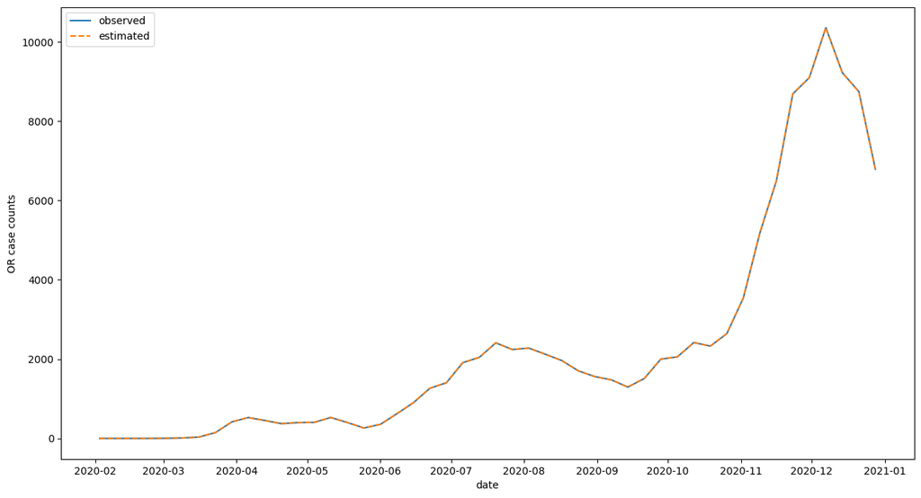

```python
plt.plot(covid.index, obs_OR, label="observed")
plt.plot(covid.index, est_OR, label="estimated", linestyle="--")
plt.legend(); plt.xlabel("date"); plt.ylabel("OR case counts");
```

Gee, we can predict the case counts *perfectly*? Does that seem very likely? What's going on?

Let's think about what we're trying to do here. We're trying to find coefficients $b_1, \ldots, b_k$ so that the the linear combination of the columns of $X$ $$ \hat y = b_1 X_{\cdot 1} + \cdots + b_k X_{\cdot k} $$ is as close to $y$ as possible.

Well, when is it possible to find $b$ so that $\hat y = y$? It is possible if $y$ is in the column space of $X$.

Recall that $X$ is an $n \times k$ matrix. If $n \le k$ then the columns of $X$ span then *entire* space $\mathbb{R}^n$ (unless for instance some columns are identical).

*Takeaway:* if you have more variables than observations (the problem is *singular* and) it is always possible to *exactly* predict the response.

*However,* these predictions are unlikely to be *generalizable*.

# Crossvalidation

How to tell how good your model is?

*See how well it predicts "new" data.*

To do $k$-fold crossvalidation:

1. Split your dataset into $k$ chunks (these should be independent!), and
2. for each chunk in turn, put it aside for "testing" and train your model on the remaining $k-1$ chunks.
3. Compare "test error" to "training error".

This can be used either as an indication of *overfitting* or to compare different models to each other.

# Crossvalidation set-up

Here's a pretty 'easy' prediction problem:

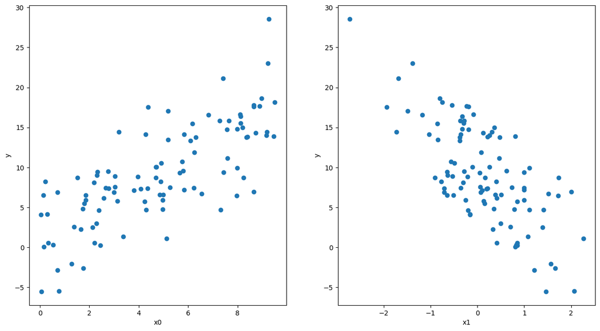

```python
n = 100
x = np.array([
    rng.uniform(low=0, high=10, size=n),
    rng.normal(size=n),
]).T
y = 2.5 + 1.5 * x[:,0] - 4.2 * x[:,1] + rng.normal(size=n)

fig, (ax0, ax1) = plt.subplots(1, 2)
ax0.scatter(x[:,0], y); ax0.set_xlabel("x0"); ax0.set_ylabel("y")
ax1.scatter(x[:,1], y); ax1.set_xlabel("x1"); ax1.set_ylabel("y");
```

Let's (a) fit a linear model and (b) do crossvalidation to look for evidence of overfitting.

```python
def rmse(X, y, model):
    yhat = model.predict(X)
    resids = y - yhat
    return np.sqrt(np.mean(resids ** 2))

def kfold(k, X, y, model):
    n  = len(y)
    folds = np.repeat(np.arange(k), np.ceil(n / k))[:n]
    rng.shuffle(folds)
    test_rmse = []
    train_rmse = []
    for ik in range(k):
        test_X = X[folds == ik]
        test_y = y[folds == ik]
        train_X = X[folds != ik]
        train_y = y[folds != ik]
        model.fit(train_X, train_y)
        test_rmse.append(rmse(test_X, test_y, model))
        train_rmse.append(rmse(train_X, train_y, model))
    return pd.DataFrame({
        "test" : test_rmse,
        "train" : train_rmse,
    })

crossval = kfold(5, x, y, lm())
crossval.mean()
```

```
test     1.121362
train    1.071623
dtype: float64
```

```python
crossval
```

|  | test | train |
| --- | --- | --- |
| 0 | 1.002842 | 1.102181 |
| 1 | 1.280119 | 1.030386 |
| 2 | 1.342009 | 1.017593 |
| 3 | 1.042074 | 1.093432 |
| 4 | 0.939767 | 1.114522 |

# When you've got too many variables

We're going to *add more variables* - these will be *independent* of everything else, so they should *not* give us meaningful predictive power for $y$. However, by chance each is a little correlated with $y$.

```python
crossval = pd.DataFrame()
for new_vars in np.linspace(0, 80, 9):
    new_x = rng.normal(size=(n, int(new_vars)))
    X = np.column_stack([x, new_x])
    xval = kfold(5, X, y, lm())
    xval["new_vars"] = int(new_vars)
    crossval = crossval.append(xval)
```

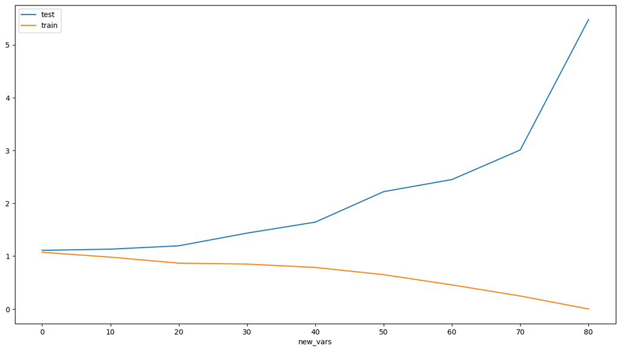

```python
crossval.groupby("new_vars").agg(np.mean).plot();
```

# Regularization

Recall that, somewhat mysteriously, scikit-learn's method to fit a Binomial GLM with a logistic link function [has a "penalty" option](https://scikit-learn.org/stable/modules/generated/sklearn.linear_model.LogisticRegression.html). What's that?

Well, it's finding $b$ to maximize the likelihood under the following model: $$ Y_i \sim \text{Binomial}(N, p(X_i \cdot b)), $$ where $p(\cdot)$ is the logistic function. The terms in the log-likelihood that depend on $b$ are $$ \sum_{i=1}^n \left\{ Y_i \log(p(X_i \cdot b)) + (N_i - Y_i) \log(1 - p(X_i \cdot b)) \right\} . $$

The problem we had above was that the variables that didn't matter had small but nonzero estimated parameters; and there were so many of them, that together they added up to something big.

*Solution:* "encourage" them to be small.

So, from our log-likelihood $$ \sum_{i=1}^n \left\{ Y_i \log(p(X_i \cdot b)) + (N_i - Y_i) \log(1 - p(X_i \cdot b)) \right\} $$ we subtract a "regularization" term that does the "encouraging". Options: $$\begin{aligned} \sum_j |b_j| \qquad & \text{"L1" or "$\ell_1$" or "lasso"}\\ \sum_j b_j^2 \qquad & \text{"L2" or "$\ell_2$" or "ridge" or "Tikhonov"} \end{aligned}$$

Let's do it, with [the Lasso](https://scikit-learn.org/stable/modules/generated/sklearn.linear_model.Lasso.html), which (since this is a standard least-squares linear model) minimizes: $$ \sum_i (y_i - X_i \cdot b)^2 + \alpha \sum_j |b_j| . $$

```python
from sklearn.linear_model import Lasso

ridge_crossval = pd.DataFrame()
for new_vars in np.linspace(0, 80, 9):
    new_x = rng.normal(size=(len(y), int(new_vars)))
    X = np.column_stack([x, new_x])
    xval = kfold(5, X, y, Lasso(alpha=.3))
    xval["new_vars"] = int(new_vars)
    ridge_crossval = ridge_crossval.append(xval)
```

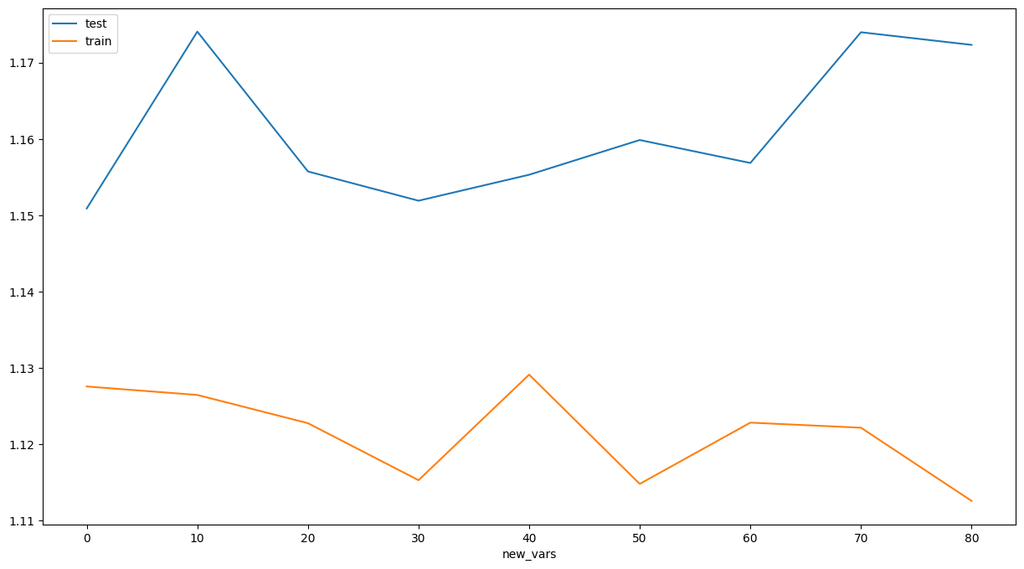

```python
ridge_crossval.groupby("new_vars").agg(np.mean).plot();
```

# An experiment

Let's see

*(a)* how well *coefficients* are estimated with the lasso, and

*(b)* how well *predictions* are made with the lasso.

To do this, we'll

1. write a function to generate a dataset, and
2. for each of many datasets, fit a model with 'lasso' regularization, then
3. look at the distribution of coefficient estimates, and
4. the distribution of residual SDs.

(IN CLASS)

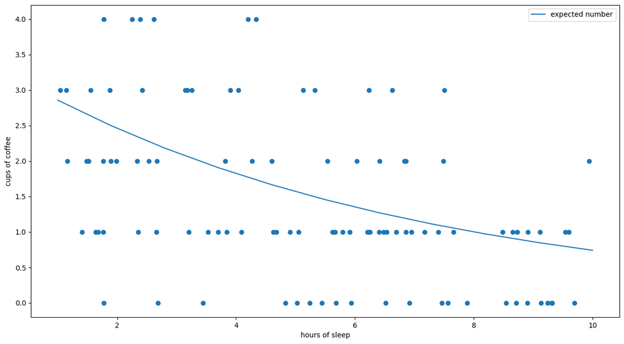

```python
true_params = {"slope": -.15, "intercept": 1.2}

def mean_cups(sleep):
    return np.exp(true_params['intercept'] + true_params['slope'] * sleep)

def sim_coffee(n):
    sleep = rng.uniform(low=1, high=10, size=n)  # not really uniform
    coffee = rng.poisson(lam=mean_cups(sleep))
    return sleep, coffee

sleep, coffee = sim_coffee(100)
plt.scatter(sleep, coffee)
plt.plot(np.linspace(1, 10, 11), mean_cups(np.linspace(1, 10, 11)), label='expected number')
plt.xlabel("hours of sleep"); plt.ylabel("cups of coffee"); plt.legend();
```

```python
from sklearn.linear_model import PoissonRegressor as poisson_glm
def fit_model(sleep, coffee, alpha):
    model = poisson_glm(alpha=alpha)
    model.fit(np.array([sleep]).T, coffee)
    return model

model = fit_model(sleep, coffee, alpha=1)
```

```python
model.coef_[0], model.intercept_
```

```
(-0.11482714727544707, 1.0905232611565594)
```

[figure not shown]

```python
plt.scatter(sleep, coffee)
plt.xlabel("hours of sleep"); plt.ylabel("cups of coffee");
coffee_hat = np.exp(model.intercept_ + model.coef_[0] * sleep)
plt.scatter(sleep, coffee_hat, label='predicted')
mean_coffee = mean_cups(sleep)
plt.scatter(sleep, mean_coffee, label='true mean')
plt.legend();
```

```python
def experiment(n, alpha):
    # n times, generate data, fit a model, and return an array of the estimated coefficients
    out = np.zeros((n, 2))
    for j in range(n):
        sleep, coffee = sim_coffee(100)
        model = fit_model(sleep, coffee, alpha)
        out[j, :] = model.coef_[0], model.intercept_
    return out

experiment(10, 1)
```

```
array([[-0.10180883,  0.89003322],
       [-0.1223202 ,  1.10556814],
       [-0.12684918,  1.10732741],
       [-0.13122881,  1.04476602],
       [-0.12383794,  1.17677132],
       [-0.16069652,  1.16739785],
       [-0.16488536,  1.33573878],
       [-0.14585712,  1.26087712],
       [-0.129308  ,  1.04148244],
       [-0.11134622,  0.92374059]])
```

```python
exp_results = experiment(300, alpha=1)
```

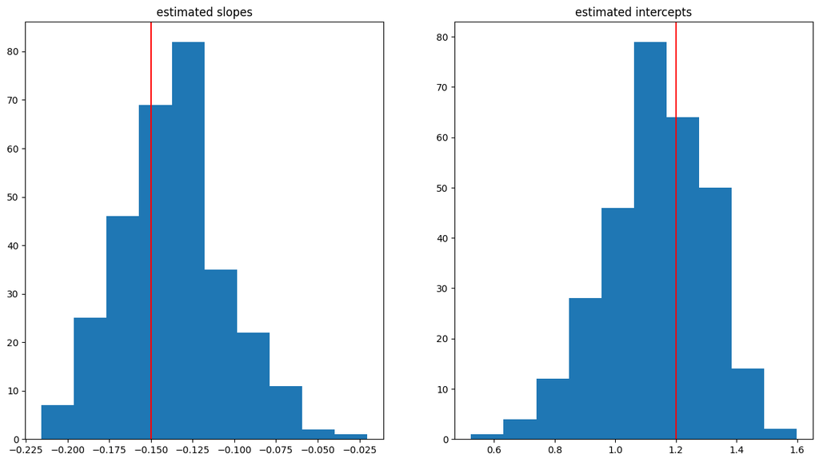

```python
fig, (ax0, ax1) = plt.subplots(1, 2)
ax0.hist(exp_results[:, 0])
ax0.set_title("estimated slopes")
ax0.axvline(true_params['slope'], color='red')
ax1.hist(exp_results[:, 1])
ax1.axvline(true_params['intercept'], color='red')
ax1.set_title("estimated intercepts")
```

Now let's look at the effect of changing alpha:

```python
alpha_vals = np.linspace(0, 30, 11)
many_experiments = np.array([experiment(100, alpha=a) for a in alpha_vals])
```

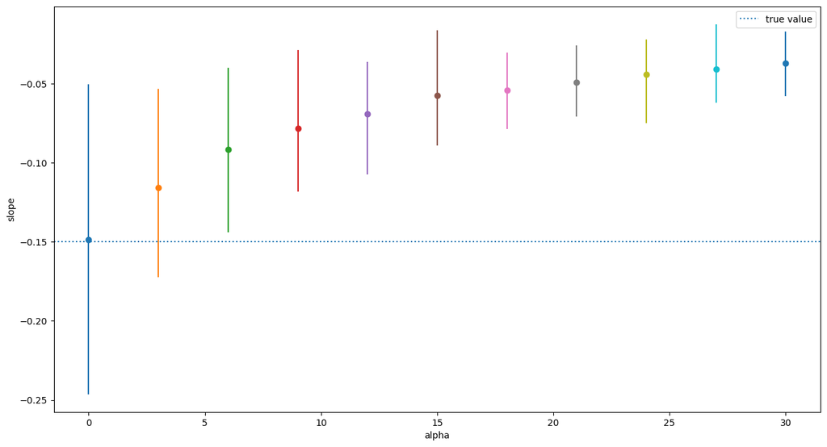

```python
min_estimates = np.min(many_experiments[:,:,0], axis=1)
max_estimates = np.max(many_experiments[:,:,0], axis=1)
mean_estimates = np.mean(many_experiments[:,:,0], axis=1)

for a, x, y, z in zip(alpha_vals, min_estimates, mean_estimates, max_estimates):
    plt.plot([a, a], [x, z])
    plt.scatter([a], [y])

plt.axhline(true_params['slope'], linestyle=":", label='true value')
plt.xlabel("alpha"); plt.ylabel("slope"); plt.legend();
```